# Prediction Assignment Writeup

Juan Felipe Padilla Sepulveda Update date: 2021-01-10

# Libraries

```r
library(tidyverse)
library(tidymodels)
library(vip)
library(skimr)
library(corrplot)
library(janitor)
library(conflicted)

conflict_prefer("filter", "dplyr")
conflict_prefer("col_factor", "readr")

theme_set(hrbrthemes::theme_ipsum())
```

# Import data

The first thing we need to do is download the training and testing sets:

```r
url_raw_training <- "https://d396qusza40orc.cloudfront.net/predmachlearn/pml-training.csv"
url_raw_testing <- "https://d396qusza40orc.cloudfront.net/predmachlearn/pml-testing.csv"

download.file(url_raw_training, "raw_training.csv")
download.file(url_raw_testing, "raw_testing.csv")
```

Then, we import the data in the appropriate format:

```r
raw_training <- read_csv(
  "raw_training.csv",
  col_types = cols(.default = col_character())
) %>%
  clean_names()

raw_testing <- read_csv(
  "raw_testing.csv",
  col_types = cols(.default = col_character())
) %>%
  clean_names()
```

The data has many columns with many missings values and it is better delete this columns from the analysis. Therefore, only the columns with a proportion of non-missing values greater that 5% are retained:

```r
valid_var <- raw_training %>%
  skim() %>%
  select(skim_type, skim_variable, complete_rate) %>%
  as_tibble() %>%
  filter(complete_rate > 0.05) %>%
  pull(skim_variable)

raw_training %<>%
  select(all_of(valid_var)) %>%
  type_convert(
    cols(
      .default = col_double(),
      user_name = col_character(),
      cvtd_timestamp = col_datetime("%d/%m/%Y %H:%M"),
      new_window = col_factor(c("yes", "no")),
      classe = col_factor(c("A", "B", "C", "D", "E"))
    )
  ) %>%
  select(-x1)

raw_testing %<>%
  select(any_of(valid_var)) %>%
  type_convert(
    cols(
      .default = col_double(),
      user_name = col_character(),
      cvtd_timestamp = col_datetime("%d/%m/%Y %H:%M"),
      new_window = col_factor(c("yes", "no")),
      classe = col_factor(c("A", "B", "C", "D", "E"))
    )
  ) %>%
  select(-x1)
```

# Exploratory Data Analysis

The main aspects of each column are show:

```r
raw_training %>%
  glimpse()
```

```
#> Rows: 19,622
#> Columns: 59
#> $ user_name            <chr> "carlitos", "carlitos", "carli...
#> $ raw_timestamp_part_1 <dbl> 1.323e+09, 1.323e+09, 1.323e+0...
#> $ raw_timestamp_part_2 <dbl> 788290, 808298, 820366, 120339...
#> $ cvtd_timestamp       <dttm> 2011-12-05 11:23:00, 2011-12-...
#> $ new_window           <fct> no, no, no, no, no, no, no, no...
#> $ num_window           <dbl> 11, 11, 11, 12, 12, 12, 12, 12...
#> $ roll_belt            <dbl> 1.41, 1.41, 1.42, 1.48, 1.48, ...
#> $ pitch_belt           <dbl> 8.07, 8.07, 8.07, 8.05, 8.07, ...
#> $ yaw_belt             <dbl> -94.4, -94.4, -94.4, -94.4, -9...
#> $ total_accel_belt     <dbl> 3, 3, 3, 3, 3, 3, 3, 3, 3, 3, ...
#> $ gyros_belt_x         <dbl> 0.00, 0.02, 0.00, 0.02, 0.02, ...
#> $ gyros_belt_y         <dbl> 0.00, 0.00, 0.00, 0.00, 0.02, ...
#> $ gyros_belt_z         <dbl> -0.02, -0.02, -0.02, -0.03, -0...
```

[output cut: 46 more lines]

```r
raw_training %>%
  skim()
```

| Name | Piped data |
| --- | --- |
| Number of rows | 19622 |
| Number of columns | 59 |
| _______________________ |  |
| Column type frequency: |  |
| character | 1 |
| factor | 2 |
| numeric | 55 |
| POSIXct | 1 |
| ________________________ |  |
| Group variables | None |

Data summary

**Variable type: character**

| skim_variable | n_missing | complete_rate | min | max | empty | n_unique | whitespace |
| --- | --- | --- | --- | --- | --- | --- | --- |
| user_name | 0 | 1 | 5 | 8 | 0 | 6 | 0 |

**Variable type: factor**

| skim_variable | n_missing | complete_rate | ordered | n_unique | top_counts |
| --- | --- | --- | --- | --- | --- |
| new_window | 0 | 1 | FALSE | 2 | no: 19216, yes: 406 |
| classe | 0 | 1 | FALSE | 5 | A: 5580, B: 3797, E: 3607, C: 3422 |

**Variable type: numeric**

| skim_variable | n_missing | complete_rate | mean | sd | p0 | p25 | p50 | p75 | p100 | hist |
| --- | --- | --- | --- | --- | --- | --- | --- | --- | --- | --- |
| raw_timestamp_part_1 | 0 | 1 | 1.323e+09 | 204927.68 | 1.322e+09 | 1.323e+09 | 1.323e+09 | 1.323e+09 | 1.323e+09 | ▃▃▇▁▆ |
| raw_timestamp_part_2 | 0 | 1 | 5.007e+05 | 288222.88 | 2.940e+02 | 2.529e+05 | 4.964e+05 | 7.519e+05 | 9.988e+05 | ▇▇▇▇▇ |
| num_window | 0 | 1 | 4.306e+02 | 247.91 | 1.000e+00 | 2.220e+02 | 4.240e+02 | 6.440e+02 | 8.640e+02 | ▇▇▇▇▇ |
| roll_belt | 0 | 1 | 6.441e+01 | 62.75 | -2.890e+01 | 1.100e+00 | 1.130e+02 | 1.230e+02 | 1.620e+02 | ▇▁▁▅▅ |
| pitch_belt | 0 | 1 | 3.100e-01 | 22.35 | -5.580e+01 | 1.760e+00 | 5.280e+00 | 1.490e+01 | 6.030e+01 | ▃▁▇▅▁ |
| yaw_belt | 0 | 1 | -1.121e+01 | 95.19 | -1.800e+02 | -8.830e+01 | -1.300e+01 | 1.290e+01 | 1.790e+02 | ▁▇▅▁▃ |
| total_accel_belt | 0 | 1 | 1.131e+01 | 7.74 | 0.000e+00 | 3.000e+00 | 1.700e+01 | 1.800e+01 | 2.900e+01 | ▇▁▂▆▁ |
| gyros_belt_x | 0 | 1 | -1.000e-02 | 0.21 | -1.040e+00 | -3.000e-02 | 3.000e-02 | 1.100e-01 | 2.220e+00 | ▁▇▁▁▁ |
| gyros_belt_y | 0 | 1 | 4.000e-02 | 0.08 | -6.400e-01 | 0.000e+00 | 2.000e-02 | 1.100e-01 | 6.400e-01 | ▁▁▇▁▁ |
| gyros_belt_z | 0 | 1 | -1.300e-01 | 0.24 | -1.460e+00 | -2.000e-01 | -1.000e-01 | -2.000e-02 | 1.620e+00 | ▁▂▇▁▁ |
| accel_belt_x | 0 | 1 | -5.590e+00 | 29.64 | -1.200e+02 | -2.100e+01 | -1.500e+01 | -5.000e+00 | 8.500e+01 | ▁▁▇▁▂ |
| accel_belt_y | 0 | 1 | 3.015e+01 | 28.58 | -6.900e+01 | 3.000e+00 | 3.500e+01 | 6.100e+01 | 1.640e+02 | ▁▇▇▁▁ |
| accel_belt_z | 0 | 1 | -7.259e+01 | 100.45 | -2.750e+02 | -1.620e+02 | -1.520e+02 | 2.700e+01 | 1.050e+02 | ▁▇▁▅▃ |
| magnet_belt_x | 0 | 1 | 5.560e+01 | 64.18 | -5.200e+01 | 9.000e+00 | 3.500e+01 | 5.900e+01 | 4.850e+02 | ▇▁▂▁▁ |
| magnet_belt_y | 0 | 1 | 5.937e+02 | 35.68 | 3.540e+02 | 5.810e+02 | 6.010e+02 | 6.100e+02 | 6.730e+02 | ▁▁▁▇▃ |
| magnet_belt_z | 0 | 1 | -3.455e+02 | 65.21 | -6.230e+02 | -3.750e+02 | -3.200e+02 | -3.060e+02 | 2.930e+02 | ▁▇▁▁▁ |
| roll_arm | 0 | 1 | 1.783e+01 | 72.74 | -1.800e+02 | -3.178e+01 | 0.000e+00 | 7.730e+01 | 1.800e+02 | ▁▃▇▆▂ |
| pitch_arm | 0 | 1 | -4.610e+00 | 30.68 | -8.880e+01 | -2.590e+01 | 0.000e+00 | 1.120e+01 | 8.850e+01 | ▁▅▇▂▁ |
| yaw_arm | 0 | 1 | -6.200e-01 | 71.36 | -1.800e+02 | -4.310e+01 | 0.000e+00 | 4.588e+01 | 1.800e+02 | ▁▃▇▃▂ |
| total_accel_arm | 0 | 1 | 2.551e+01 | 10.52 | 1.000e+00 | 1.700e+01 | 2.700e+01 | 3.300e+01 | 6.600e+01 | ▃▆▇▁▁ |
| gyros_arm_x | 0 | 1 | 4.000e-02 | 1.99 | -6.370e+00 | -1.330e+00 | 8.000e-02 | 1.570e+00 | 4.870e+00 | ▁▃▇▆▂ |
| gyros_arm_y | 0 | 1 | -2.600e-01 | 0.85 | -3.440e+00 | -8.000e-01 | -2.400e-01 | 1.400e-01 | 2.840e+00 | ▁▂▇▂▁ |
| gyros_arm_z | 0 | 1 | 2.700e-01 | 0.55 | -2.330e+00 | -7.000e-02 | 2.300e-01 | 7.200e-01 | 3.020e+00 | ▁▂▇▂▁ |
| accel_arm_x | 0 | 1 | -6.024e+01 | 182.04 | -4.040e+02 | -2.420e+02 | -4.400e+01 | 8.400e+01 | 4.370e+02 | ▇▅▇▅▁ |
| accel_arm_y | 0 | 1 | 3.260e+01 | 109.87 | -3.180e+02 | -5.400e+01 | 1.400e+01 | 1.390e+02 | 3.080e+02 | ▁▃▇▆▂ |
| accel_arm_z | 0 | 1 | -7.125e+01 | 134.65 | -6.360e+02 | -1.430e+02 | -4.700e+01 | 2.300e+01 | 2.920e+02 | ▁▁▅▇▁ |
| magnet_arm_x | 0 | 1 | 1.917e+02 | 443.64 | -5.840e+02 | -3.000e+02 | 2.890e+02 | 6.370e+02 | 7.820e+02 | ▆▃▂▃▇ |
| magnet_arm_y | 0 | 1 | 1.566e+02 | 201.91 | -3.920e+02 | -9.000e+00 | 2.020e+02 | 3.230e+02 | 5.830e+02 | ▁▅▅▇▂ |
| magnet_arm_z | 0 | 1 | 3.065e+02 | 326.62 | -5.970e+02 | 1.312e+02 | 4.440e+02 | 5.450e+02 | 6.940e+02 | ▁▂▂▃▇ |
| roll_dumbbell | 0 | 1 | 2.384e+01 | 69.93 | -1.537e+02 | -1.849e+01 | 4.817e+01 | 6.761e+01 | 1.536e+02 | ▂▂▃▇▂ |
| pitch_dumbbell | 0 | 1 | -1.078e+01 | 36.99 | -1.496e+02 | -4.089e+01 | -2.096e+01 | 1.750e+01 | 1.494e+02 | ▁▆▇▂▁ |
| yaw_dumbbell | 0 | 1 | 1.670e+00 | 82.52 | -1.509e+02 | -7.764e+01 | -3.320e+00 | 7.964e+01 | 1.549e+02 | ▃▇▅▅▆ |
| total_accel_dumbbell | 0 | 1 | 1.372e+01 | 10.23 | 0.000e+00 | 4.000e+00 | 1.000e+01 | 1.900e+01 | 5.800e+01 | ▇▅▃▁▁ |
| gyros_dumbbell_x | 0 | 1 | 1.600e-01 | 1.51 | -2.040e+02 | -3.000e-02 | 1.300e-01 | 3.500e-01 | 2.220e+00 | ▁▁▁▁▇ |
| gyros_dumbbell_y | 0 | 1 | 5.000e-02 | 0.61 | -2.100e+00 | -1.400e-01 | 3.000e-02 | 2.100e-01 | 5.200e+01 | ▇▁▁▁▁ |
| gyros_dumbbell_z | 0 | 1 | -1.300e-01 | 2.29 | -2.380e+00 | -3.100e-01 | -1.300e-01 | 3.000e-02 | 3.170e+02 | ▇▁▁▁▁ |
| accel_dumbbell_x | 0 | 1 | -2.862e+01 | 67.32 | -4.190e+02 | -5.000e+01 | -8.000e+00 | 1.100e+01 | 2.350e+02 | ▁▁▆▇▁ |
| accel_dumbbell_y | 0 | 1 | 5.263e+01 | 80.75 | -1.890e+02 | -8.000e+00 | 4.150e+01 | 1.110e+02 | 3.150e+02 | ▁▇▇▅▁ |
| accel_dumbbell_z | 0 | 1 | -3.832e+01 | 109.47 | -3.340e+02 | -1.420e+02 | -1.000e+00 | 3.800e+01 | 3.180e+02 | ▁▆▇▃▁ |
| magnet_dumbbell_x | 0 | 1 | -3.285e+02 | 339.72 | -6.430e+02 | -5.350e+02 | -4.790e+02 | -3.040e+02 | 5.920e+02 | ▇▂▁▁▂ |
| magnet_dumbbell_y | 0 | 1 | 2.210e+02 | 326.87 | -3.600e+03 | 2.310e+02 | 3.110e+02 | 3.900e+02 | 6.330e+02 | ▁▁▁▁▇ |
| magnet_dumbbell_z | 0 | 1 | 4.605e+01 | 139.96 | -2.620e+02 | -4.500e+01 | 1.300e+01 | 9.500e+01 | 4.520e+02 | ▁▇▆▂▂ |
| roll_forearm | 0 | 1 | 3.383e+01 | 108.04 | -1.800e+02 | -7.400e-01 | 2.170e+01 | 1.400e+02 | 1.800e+02 | ▃▂▇▂▇ |
| pitch_forearm | 0 | 1 | 1.071e+01 | 28.15 | -7.250e+01 | 0.000e+00 | 9.240e+00 | 2.840e+01 | 8.980e+01 | ▁▁▇▃▁ |
| yaw_forearm | 0 | 1 | 1.921e+01 | 103.22 | -1.800e+02 | -6.860e+01 | 0.000e+00 | 1.100e+02 | 1.800e+02 | ▅▅▇▆▇ |
| total_accel_forearm | 0 | 1 | 3.472e+01 | 10.06 | 0.000e+00 | 2.900e+01 | 3.600e+01 | 4.100e+01 | 1.080e+02 | ▁▇▂▁▁ |
| gyros_forearm_x | 0 | 1 | 1.600e-01 | 0.65 | -2.200e+01 | -2.200e-01 | 5.000e-02 | 5.600e-01 | 3.970e+00 | ▁▁▁▁▇ |
| gyros_forearm_y | 0 | 1 | 8.000e-02 | 3.10 | -7.020e+00 | -1.460e+00 | 3.000e-02 | 1.620e+00 | 3.110e+02 | ▇▁▁▁▁ |
| gyros_forearm_z | 0 | 1 | 1.500e-01 | 1.75 | -8.090e+00 | -1.800e-01 | 8.000e-02 | 4.900e-01 | 2.310e+02 | ▇▁▁▁▁ |
| accel_forearm_x | 0 | 1 | -6.165e+01 | 180.59 | -4.980e+02 | -1.780e+02 | -5.700e+01 | 7.600e+01 | 4.770e+02 | ▂▆▇▅▁ |
| accel_forearm_y | 0 | 1 | 1.637e+02 | 200.13 | -6.320e+02 | 5.700e+01 | 2.010e+02 | 3.120e+02 | 9.230e+02 | ▁▂▇▅▁ |
| accel_forearm_z | 0 | 1 | -5.529e+01 | 138.40 | -4.460e+02 | -1.820e+02 | -3.900e+01 | 2.600e+01 | 2.910e+02 | ▁▇▅▅▃ |
| magnet_forearm_x | 0 | 1 | -3.126e+02 | 346.96 | -1.280e+03 | -6.160e+02 | -3.780e+02 | -7.300e+01 | 6.720e+02 | ▁▇▇▅▁ |
| magnet_forearm_y | 0 | 1 | 3.801e+02 | 509.37 | -8.960e+02 | 2.000e+00 | 5.910e+02 | 7.370e+02 | 1.480e+03 | ▂▂▂▇▁ |
| magnet_forearm_z | 0 | 1 | 3.936e+02 | 369.27 | -9.730e+02 | 1.910e+02 | 5.110e+02 | 6.530e+02 | 1.090e+03 | ▁▁▂▇▃ |

**Variable type: POSIXct**

| skim_variable | n_missing | complete_rate | min | max | median | n_unique |
| --- | --- | --- | --- | --- | --- | --- |
| cvtd_timestamp | 0 | 1 | 2011-11-28 14:13:00 | 2011-12-05 14:24:00 | 2011-12-02 13:35:00 | 20 |

Likewise, a correlogram is plotted showing the correlation between all variables:

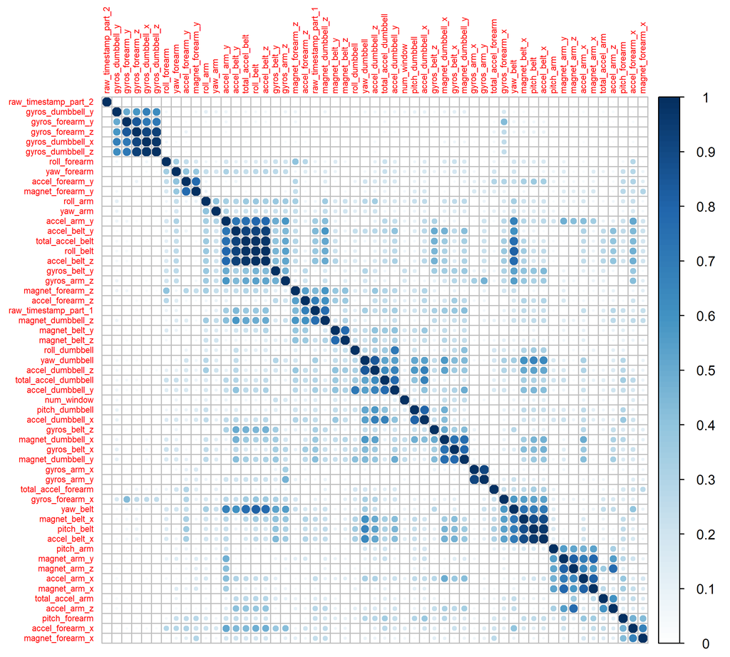

```r
corrplot(
  raw_training %>%
    select(where(is.numeric)) %>%
    cor() %>%
    abs(),
  order = "hclust",
  tl.cex = 0.5,
  cl.lim = c(0, 1)
)
```

# Model

## Splitting

The data is split into training and testing sets, 80% and 20% respectively.

```r
data_split <- initial_split(raw_training, prop = 4 / 5, strata = classe)
data_training <- training(data_split)
data_test <- testing(data_split)
```

## Preprocessing

The first six variables are identification of each row and we removed from list of predictors. Also, we remove all variables with zero variance, near-zero variance and highly correlated.

```r
main_rec <- recipe(classe ~ ., data_training) %>%
  update_role(
    user_name,
    raw_timestamp_part_1,
    raw_timestamp_part_2,
    cvtd_timestamp,
    new_window,
    num_window,
    new_role = "ID"
  ) %>%
  step_zv(all_predictors()) %>%
  step_nzv(all_predictors()) %>%
  step_corr(all_predictors())
```

The preprocessing steps left only 45 variables for prediction:

```r
prepped_rec <- prep(main_rec, verbose = TRUE, retain = TRUE)
```

```
#> oper 1 step zv [training]
#> oper 2 step nzv [training]
#> oper 3 step corr [training]
#> The retained training set is ~ 6.06 Mb  in memory.
```

```r
baked_train <- bake(prepped_rec, new_data = NULL)

predictors_model <- baked_train %>%
  select(
    any_of(
      prepped_rec[["var_info"]] %>%
        filter(role == "predictor") %>%
        pull(variable)
    )
  )

baked_train %>%
  glimpse()
```

```
#> Rows: 15,700
#> Columns: 52
#> $ user_name            <fct> carlitos, carlitos, carlitos, ...
#> $ raw_timestamp_part_1 <dbl> 1.323e+09, 1.323e+09, 1.323e+0...
#> $ raw_timestamp_part_2 <dbl> 788290, 808298, 820366, 120339...
#> $ cvtd_timestamp       <dttm> 2011-12-05 11:23:00, 2011-12-...
#> $ new_window           <fct> no, no, no, no, no, no, no, no...
#> $ num_window           <dbl> 11, 11, 11, 12, 12, 12, 12, 12...
#> $ pitch_belt           <dbl> 8.07, 8.07, 8.07, 8.05, 8.07, ...
#> $ yaw_belt             <dbl> -94.4, -94.4, -94.4, -94.4, -9...
#> $ total_accel_belt     <dbl> 3, 3, 3, 3, 3, 3, 3, 3, 3, 3, ...
#> $ gyros_belt_x         <dbl> 0.00, 0.02, 0.00, 0.02, 0.02, ...
#> $ gyros_belt_y         <dbl> 0.00, 0.00, 0.00, 0.00, 0.02, ...
#> $ gyros_belt_z         <dbl> -0.02, -0.02, -0.02, -0.03, -0...
#> $ magnet_belt_x        <dbl> -3, -7, -2, -6, -6, 0, -2, 1, ...
```

[output cut: 39 more lines]

```r
baked_test <- bake(prepped_rec, new_data = data_test)

baked_test %>%
  glimpse()
```

```
#> Rows: 3,922
#> Columns: 52
#> $ user_name            <fct> carlitos, carlitos, carlitos, ...
#> $ raw_timestamp_part_1 <dbl> 1.323e+09, 1.323e+09, 1.323e+0...
#> $ raw_timestamp_part_2 <dbl> 368296, 604281, 996313, 120363...
#> $ cvtd_timestamp       <dttm> 2011-12-05 11:23:00, 2011-12-...
#> $ new_window           <fct> no, no, yes, no, no, no, no, n...
#> $ num_window           <dbl> 12, 12, 12, 13, 13, 13, 13, 13...
#> $ pitch_belt           <dbl> 8.09, 8.20, 8.10, 8.14, 8.18, ...
#> $ yaw_belt             <dbl> -94.4, -94.4, -94.4, -94.4, -9...
#> $ total_accel_belt     <dbl> 3, 3, 3, 3, 3, 3, 3, 3, 3, 3, ...
#> $ gyros_belt_x         <dbl> 0.02, 0.00, 0.02, 0.03, 0.02, ...
#> $ gyros_belt_y         <dbl> 0.00, 0.00, 0.00, 0.00, 0.02, ...
#> $ gyros_belt_z         <dbl> -0.02, 0.00, -0.02, -0.02, -0....
#> $ magnet_belt_x        <dbl> -4, -1, -3, -4, -6, 1, 0, -1, ...
```

[output cut: 39 more lines]

# Specification of the model

We choose a random forest model because out-of-the-box performance. The number of trees is chosen to be ten times the number of predictors (450):

```r
(n_trees <- ncol(predictors_model) * 10)
```

```
#> [1] 450
```

```r
main_model <- rand_forest(
  trees = 450,
  mtry = tune(),
  min_n = tune()
) %>%
  set_engine(
    "ranger",
    num.threads = parallel::detectCores(),
    respect.unordered.factors = "order",
    importance = "impurity"
  ) %>%
  set_mode("classification")
```

```r
model_workflow <- workflow() %>%
  add_model(main_model) %>%
  add_recipe(main_rec)
```

## Hyperparameters tuning

We search for the best values for the the number of features to consider at any given split and the complexity of each tree. Moreover, we use five resamples of the training data and five levels for each hyperparameter:

```r
doParallel::registerDoParallel(cores = parallel::detectCores())

folds <- vfold_cv(data_training, v = 5)

main_grid <- grid_regular(
  finalize(mtry(), predictors_model),
  min_n(),
  levels = 5
)

main_tuning <- model_workflow %>%
  tune_grid(
    resamples = folds,
    grid = main_grid,
    control = control_grid(save_pred = TRUE),
    metrics = metric_set(roc_auc)
  )
```

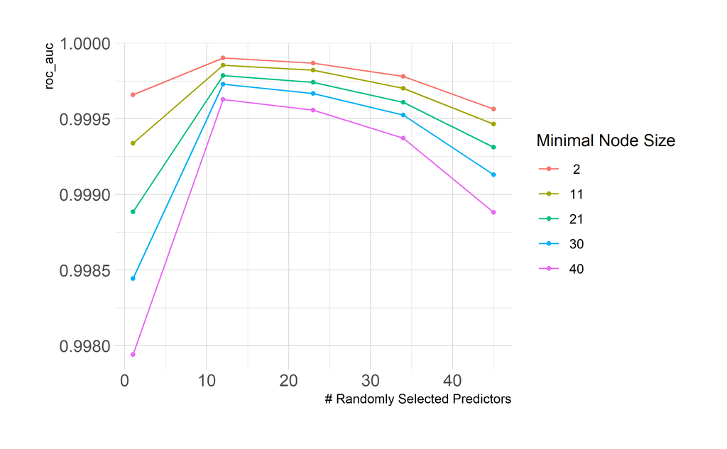

```r
main_tuning %>%
  autoplot()
```

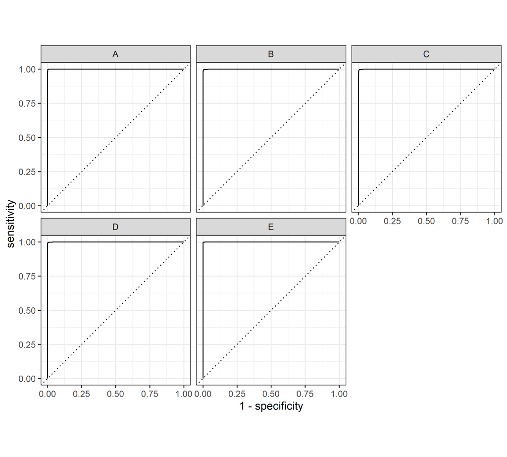

```r
main_best <- main_tuning %>%
  select_best()

main_pred_val <- main_tuning %>%
  collect_predictions(parameters = main_best) %>%
  roc_curve(
    ".pred_A",
    ".pred_B",
    ".pred_C",
    ".pred_D",
    ".pred_E",
    truth = classe
  )

autoplot(main_pred_val)
```

# Final model

## Performance

We estimate the model with hyperparameters of the best model from previous section:

```r
final_workflow <- model_workflow %>%
  finalize_workflow(main_best)

last_fit_main <- final_workflow %>%
  last_fit(data_split)
```

The metrics for the final model are really good showing an accuracy of 0.99 and area under the curve from 1:

```r
last_fit_main %>%
  collect_metrics()
```

```
#> # A tibble: 2 x 4
#>   .metric  .estimator .estimate .config
#>   <chr>    <chr>          <dbl> <chr>
#> 1 accuracy multiclass     0.996 Preprocessor1_Model1
#> 2 roc_auc  hand_till      1.00  Preprocessor1_Model1
```

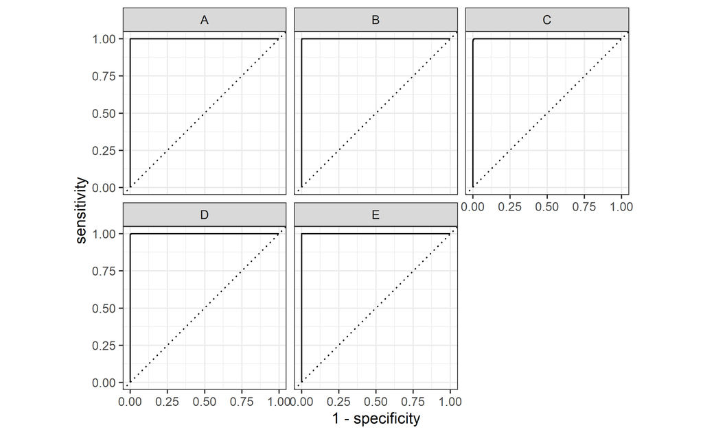

```r
model_pred <- last_fit_main %>%
  collect_predictions()

model_pred %>%
  roc_curve(
    ".pred_A",
    ".pred_B",
    ".pred_C",
    ".pred_D",
    ".pred_E",
    truth = classe
  ) %>%
  autoplot()
```

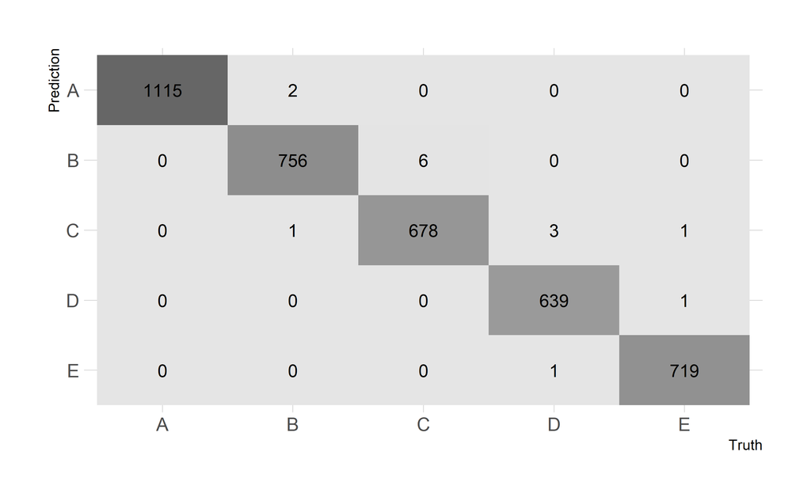

```r
conf_mat(
  model_pred,
  truth = classe,
  estimate = .pred_class
) %>%
  autoplot(type = "heatmap")
```

## Feature importance

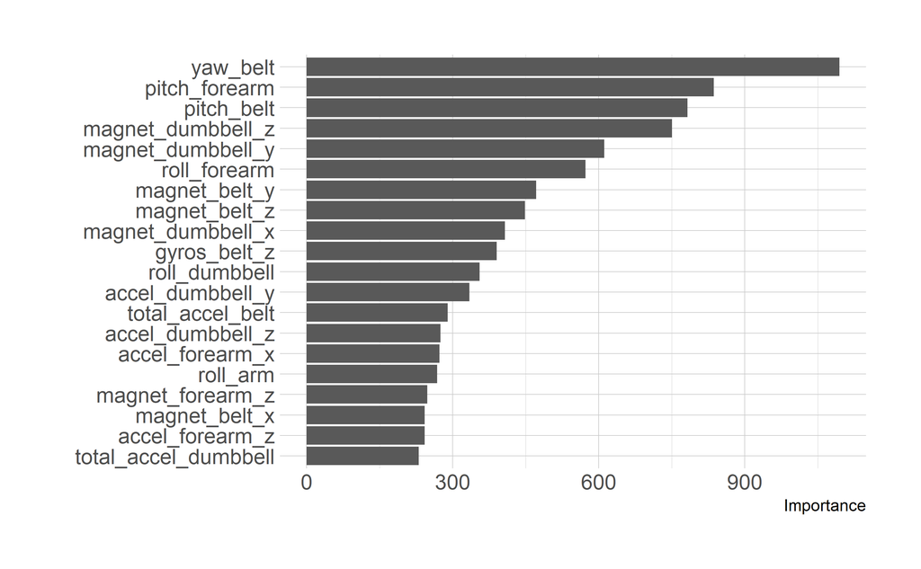

```r
last_fit_main %>%
  pluck(".workflow", 1) %>%
  pull_workflow_fit() %>%
  vip(num_features = 20)
```